# P2

2022-10-29

## Describe the data

Load the data

```r
df <- read.csv('diamonds.csv', header = TRUE)

df <- df[, -1]
y = df$price
df = df[,-7]  # get rid of price
names(df)[7:9] = c("xx","yy","zz") # rename (x,y,z)
df = cbind(df,y) # tack price back on, as a column named y

head(df, 10)
```

```
##    carat       cut color clarity depth table   xx   yy   zz   y
## 1   0.23     Ideal     E     SI2  61.5    55 3.95 3.98 2.43 326
## 2   0.21   Premium     E     SI1  59.8    61 3.89 3.84 2.31 326
## 3   0.23      Good     E     VS1  56.9    65 4.05 4.07 2.31 327
## 4   0.29   Premium     I     VS2  62.4    58 4.20 4.23 2.63 334
## 5   0.31      Good     J     SI2  63.3    58 4.34 4.35 2.75 335
## 6   0.24 Very Good     J    VVS2  62.8    57 3.94 3.96 2.48 336
## 7   0.24 Very Good     I    VVS1  62.3    57 3.95 3.98 2.47 336
## 8   0.26 Very Good     H     SI1  61.9    55 4.07 4.11 2.53 337
## 9   0.22      Fair     E     VS2  65.1    61 3.87 3.78 2.49 337
## 10  0.23 Very Good     H     VS1  59.4    61 4.00 4.05 2.39 338
```

describe the data (summary and sample size). Before the summary, factorize ‘cut’, ‘color’, and ‘clarity’. And apparently ‘X’ is the serial number for each row, which is redundant, so we will delete that.

```r
df$cut <- factor(df$cut)
df$color <- factor(df$color)
df$clarity <- factor(df$clarity)

summary(df)
```

```
##      carat               cut        color        clarity          depth
##  Min.   :0.2000   Fair     : 1610   D: 6775   SI1    :13065   Min.   :43.00
##  1st Qu.:0.4000   Good     : 4906   E: 9797   VS2    :12258   1st Qu.:61.00
##  Median :0.7000   Ideal    :21551   F: 9542   SI2    : 9194   Median :61.80
##  Mean   :0.7979   Premium  :13791   G:11292   VS1    : 8171   Mean   :61.75
##  3rd Qu.:1.0400   Very Good:12082   H: 8304   VVS2   : 5066   3rd Qu.:62.50
##  Max.   :5.0100                     I: 5422   VVS1   : 3655   Max.   :79.00
##                                     J: 2808   (Other): 2531
##      table             xx               yy               zz
##  Min.   :43.00   Min.   : 0.000   Min.   : 0.000   Min.   : 0.000
##  1st Qu.:56.00   1st Qu.: 4.710   1st Qu.: 4.720   1st Qu.: 2.910
##  Median :57.00   Median : 5.700   Median : 5.710   Median : 3.530
##  Mean   :57.46   Mean   : 5.731   Mean   : 5.735   Mean   : 3.539
##  3rd Qu.:59.00   3rd Qu.: 6.540   3rd Qu.: 6.540   3rd Qu.: 4.040
##  Max.   :95.00   Max.   :10.740   Max.   :58.900   Max.   :31.800
##
##        y
##  Min.   :  326
##  1st Qu.:  950
##  Median : 2401
##  Mean   : 3933
##  3rd Qu.: 5324
##  Max.   :18823
##
```

```r
nrow(df)
```

```
## [1] 53940
```

## Concise EDA

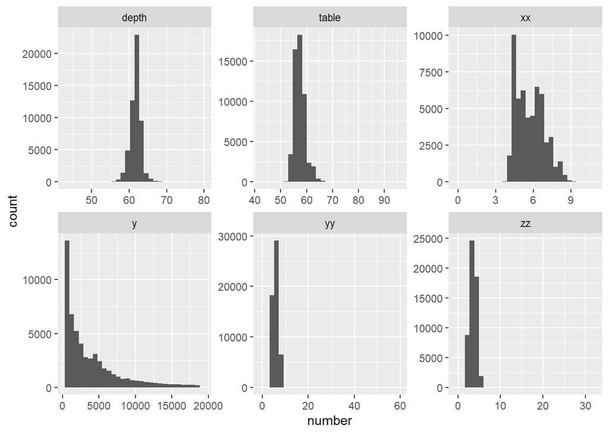

```r
suppressMessages(library(tidyverse))

n <- gather(df %>% select(.,depth, table, y, xx, yy, zz), key = 'character', value = 'number')
ggplot(data = n, mapping=aes(x = number)) +
  geom_histogram() +
  facet_wrap(~character, scales = 'free')
```

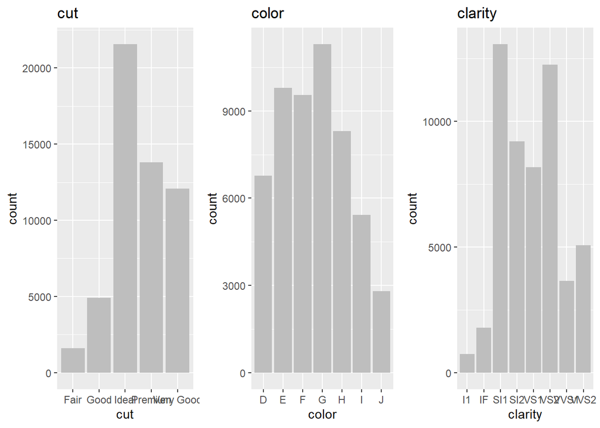

```r
suppressMessages(library(ggpubr))

p1 <- ggplot(data = df %>% select(cut), mapping=aes(x=cut)) +
  geom_bar(fill = "gray") +
  ggtitle("cut")

p2 <- ggplot(data = df %>% select(color), mapping=aes(x=color)) +
   geom_bar(fill = "gray") +
  ggtitle("color")

p3 <- ggplot(data = df %>% select(clarity), mapping=aes(x=clarity)) +
  geom_bar(fill = "gray") +
  ggtitle("clarity")

ggarrange(p1, p2, p3, ncol = 3, nrow = 1)
```

Now let’s take a look at the outliers. ‘z’ has a large gap between 3rd Qu. and MAX.

```r
head(df[order(-df$zz),], 10)
```

```
##       carat       cut color clarity depth table    xx    yy    zz     y
## 48411  0.51 Very Good     E     VS1  61.8  54.7  5.12  5.15 31.80  1970
## 24068  2.00   Premium     H     SI2  58.9  57.0  8.09 58.90  8.06 12210
## 27416  5.01      Fair     J      I1  65.5  59.0 10.74 10.54  6.98 18018
## 27631  4.50      Fair     J      I1  65.8  58.0 10.23 10.16  6.72 18531
## 27131  4.13      Fair     H      I1  64.8  61.0 10.00  9.85  6.43 17329
## 23645  3.65      Fair     H      I1  67.1  53.0  9.53  9.48  6.38 11668
## 26445  4.00 Very Good     I      I1  63.3  58.0 10.01  9.94  6.31 15984
## 26432  3.40      Fair     D      I1  66.8  52.0  9.42  9.34  6.27 15964
## 26000  4.01   Premium     J      I1  62.5  62.0 10.02  9.94  6.24 15223
## 25999  4.01   Premium     I      I1  61.0  61.0 10.14 10.10  6.17 15223
```

Clearly the sample with ‘z’ being 31.8 is an outlier and we should delete it.

```r
df <- filter(df, df$zz < 30)
nrow(df)
```

```
## [1] 53939
```

Do the same with ‘y’.

```r
head(df[order(-df$yy),], 10)
```

```
##       carat       cut color clarity depth table    xx    yy   zz     y
## 24068  2.00   Premium     H     SI2  58.9    57  8.09 58.90 8.06 12210
## 49189  0.51     Ideal     E     VS1  61.8    55  5.15 31.80 5.12  2075
## 27416  5.01      Fair     J      I1  65.5    59 10.74 10.54 6.98 18018
## 27631  4.50      Fair     J      I1  65.8    58 10.23 10.16 6.72 18531
## 25999  4.01   Premium     I      I1  61.0    61 10.14 10.10 6.17 15223
## 26000  4.01   Premium     J      I1  62.5    62 10.02  9.94 6.24 15223
## 26445  4.00 Very Good     I      I1  63.3    58 10.01  9.94 6.31 15984
## 27131  4.13      Fair     H      I1  64.8    61 10.00  9.85 6.43 17329
## 26535  3.67   Premium     I      I1  62.4    56  9.86  9.81 6.13 16193
## 27680  3.51   Premium     J     VS2  62.5    59  9.66  9.63 6.03 18701
```

Clearly the sample with the highest two ‘y’ are outliers and we should delete them.

```r
df <- filter(df, df$yy < 30)
nrow(df)
```

```
## [1] 53937
```

Do the same with ‘x’.

```r
head(df[order(-df$xx),], 10)
```

```
##       carat       cut color clarity depth table    xx    yy   zz     y
## 27415  5.01      Fair     J      I1  65.5    59 10.74 10.54 6.98 18018
## 27630  4.50      Fair     J      I1  65.8    58 10.23 10.16 6.72 18531
## 25998  4.01   Premium     I      I1  61.0    61 10.14 10.10 6.17 15223
## 25999  4.01   Premium     J      I1  62.5    62 10.02  9.94 6.24 15223
## 26444  4.00 Very Good     I      I1  63.3    58 10.01  9.94 6.31 15984
## 27130  4.13      Fair     H      I1  64.8    61 10.00  9.85 6.43 17329
## 26534  3.67   Premium     I      I1  62.4    56  9.86  9.81 6.13 16193
## 27679  3.51   Premium     J     VS2  62.5    59  9.66  9.63 6.03 18701
## 24328  3.50     Ideal     H      I1  62.8    57  9.65  9.59 6.03 12587
## 22742  3.01      Fair     H      I1  56.1    62  9.54  9.38 5.31 10761
```

```r
head(df[order(df$xx),], 10)
```

```
##       carat       cut color clarity depth table   xx   yy   zz     y
## 11183  1.07     Ideal     F     SI2  61.6    56 0.00 6.62 0.00  4954
## 11964  1.00 Very Good     H     VS2  63.3    53 0.00 0.00 0.00  5139
## 15952  1.14      Fair     G     VS1  57.5    67 0.00 0.00 0.00  6381
## 24520  1.56     Ideal     G     VS2  62.2    54 0.00 0.00 0.00 12800
## 26243  1.20   Premium     D    VVS1  62.1    59 0.00 0.00 0.00 15686
## 27429  2.25   Premium     H     SI2  62.8    59 0.00 0.00 0.00 18034
## 49554  0.71      Good     F     SI2  64.1    60 0.00 0.00 0.00  2130
## 49555  0.71      Good     F     SI2  64.1    60 0.00 0.00 0.00  2130
## 31596  0.20   Premium     F     VS2  62.6    59 3.73 3.71 2.33   367
## 31600  0.20   Premium     D     VS2  62.3    60 3.73 3.68 2.31   367
```

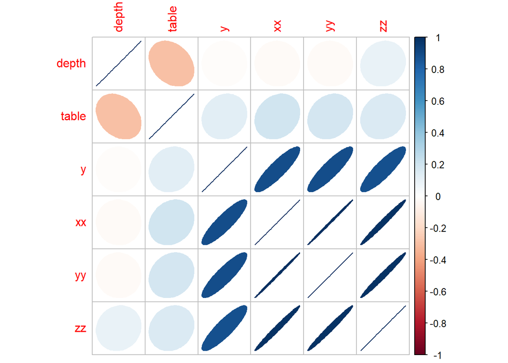

```r
suppressMessages(library(corrplot))

df %>%
  dplyr::select(.,depth, table, y, xx, yy, zz) %>%
  cor(.) %>%
  corrplot(.,method="ellipse")
```

## Split the data

Split the data into train and test (7:3)

```r
set.seed(505)
s <- sample(nrow(df),round(0.7*nrow(df)))
train <- df[s,]
test <- df[-s,]
```

## Linear regression analysis

```r
lm.out <- lm(y~.,data=train)
summary(lm.out)
```

```
##
## Call:
## lm(formula = y ~ ., data = train)
##
## Residuals:
##      Min       1Q   Median       3Q      Max
## -21000.6   -593.8   -183.4    374.1  10254.2
##
## Coefficients:
##               Estimate Std. Error t value Pr(>|t|)
## (Intercept)   1635.470    531.949   3.074  0.00211 **
## carat        11149.394     57.929 192.467  < 2e-16 ***
## cutGood        589.871     40.197  14.674  < 2e-16 ***
## cutIdeal       830.395     39.773  20.878  < 2e-16 ***
## cutPremium     777.522     38.087  20.414  < 2e-16 ***
## cutVery Good   725.892     38.719  18.748  < 2e-16 ***
## colorE        -201.750     21.341  -9.454  < 2e-16 ***
## colorF        -268.992     21.596 -12.456  < 2e-16 ***
## colorG        -474.502     21.135 -22.451  < 2e-16 ***
## colorH        -980.017     22.527 -43.504  < 2e-16 ***
## colorI       -1452.012     25.314 -57.359  < 2e-16 ***
## colorJ       -2351.739     31.168 -75.455  < 2e-16 ***
## clarityIF     5390.099     60.888  88.525  < 2e-16 ***
## claritySI1    3715.439     51.815  71.705  < 2e-16 ***
## claritySI2    2760.253     52.006  53.076  < 2e-16 ***
## clarityVS1    4624.888     52.906  87.417  < 2e-16 ***
## clarityVS2    4312.830     52.083  82.808  < 2e-16 ***
## clarityVVS1   5047.383     56.115  89.946  < 2e-16 ***
## clarityVVS2   4975.156     54.458  91.357  < 2e-16 ***
## depth          -58.751      6.408  -9.168  < 2e-16 ***
## table          -26.001      3.474  -7.485 7.33e-14 ***
## xx           -1326.971    103.040 -12.878  < 2e-16 ***
## yy             416.868    100.466   4.149 3.34e-05 ***
## zz            -126.571     70.853  -1.786  0.07404 .
## ---
## Signif. codes:  0 '***' 0.001 '**' 0.01 '*' 0.05 '.' 0.1 ' ' 1
##
## Residual standard error: 1129 on 37732 degrees of freedom
## Multiple R-squared:  0.9197, Adjusted R-squared:  0.9197
## F-statistic: 1.88e+04 on 23 and 37732 DF,  p-value: < 2.2e-16
```

The adjusted R square is 0.9197, which mkaes the model useful.

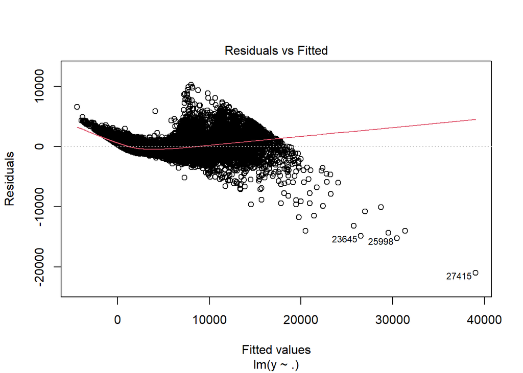

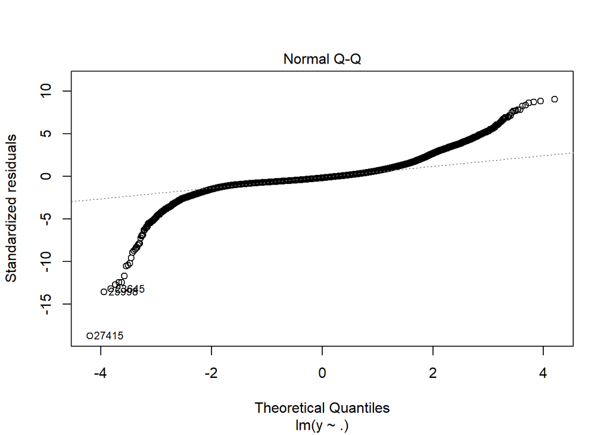

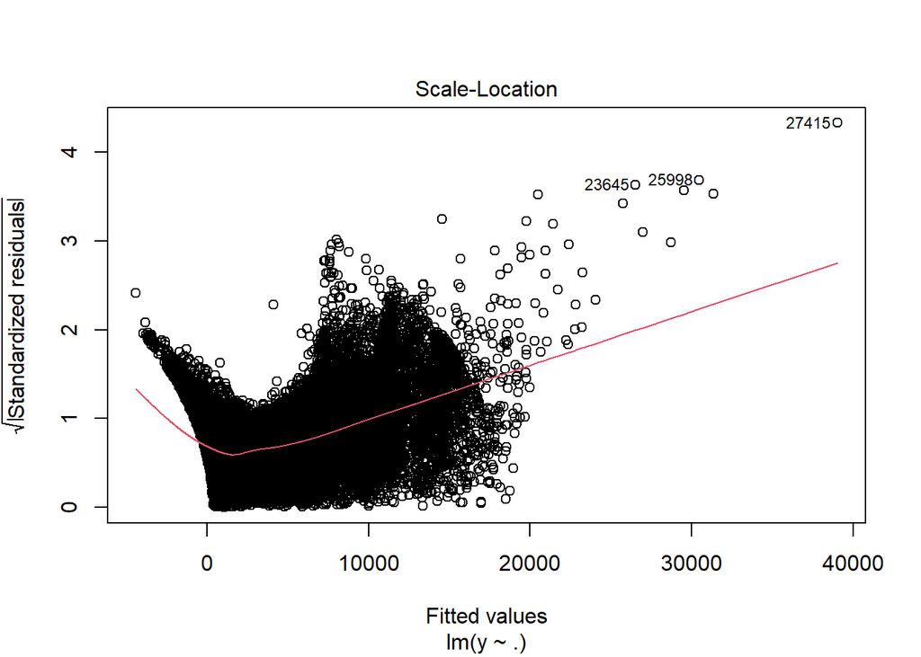

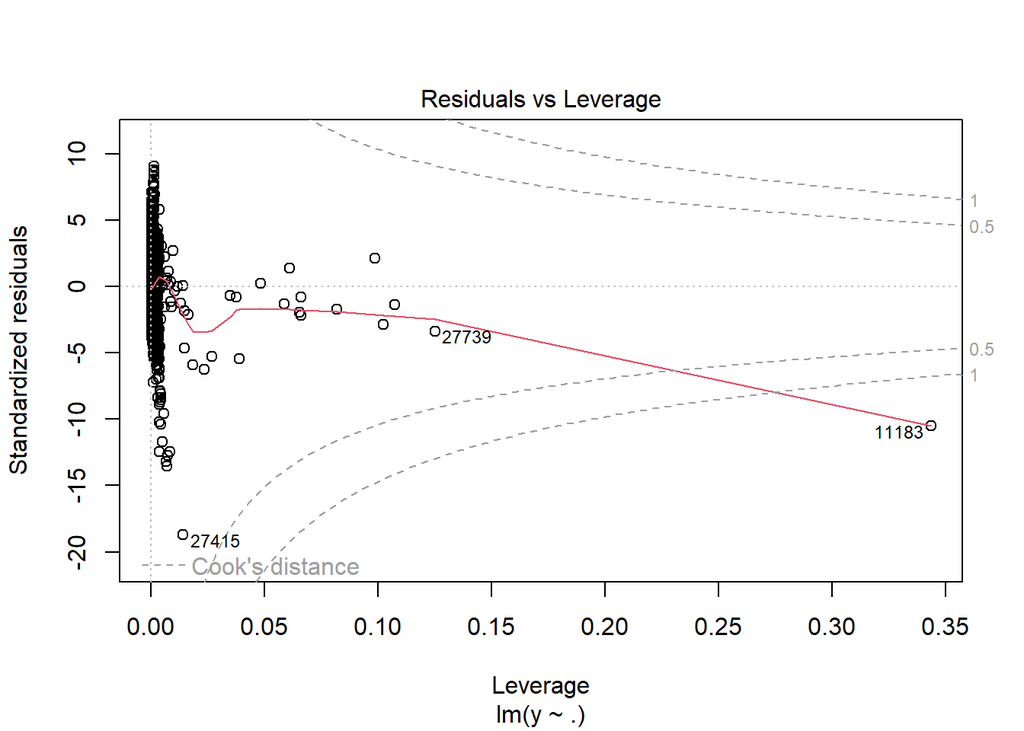

```r
plot(lm.out)
```

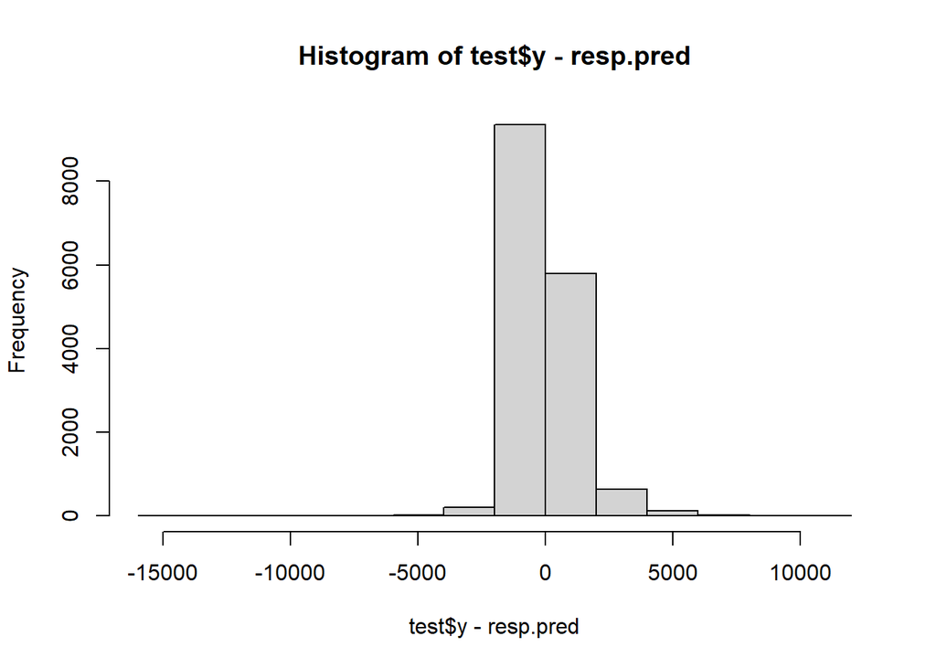

```r
resp.pred <- predict(lm.out, newdata=test)
hist(test$y - resp.pred)
```

The histogram of the residuals between the observed test-set response values and the predicted test-set response values looks normal.

```r
Cost.pred <- predict(lm.out,newdata=test)
mean((Cost.pred-test$y)^2)
```

```
## [1] 1279551
```

the MSE is 1279551.

```r
library(bestglm)
out.bg.bic <- bestglm(train,family=gaussian,IC="BIC")
```

```
## Morgan-Tatar search since factors present with more than 2 levels.
```

```r
out.bg.bic$BestModel
```

```
##
## Call:
## lm(formula = y ~ ., data = data.frame(Xy[, c(bestset[-1], FALSE),
##     drop = FALSE], y = y))
##
## Coefficients:
##  (Intercept)         carat       cutGood      cutIdeal    cutPremium
##      2095.10      11149.26        591.89        831.77        779.65
## cutVery Good        colorE        colorF        colorG        colorH
##       726.94       -201.74       -268.90       -474.25       -979.79
##       colorI        colorJ     clarityIF    claritySI1    claritySI2
##     -1451.76      -2352.01       5387.36       3713.09       2758.05
##   clarityVS1    clarityVS2   clarityVVS1   clarityVVS2         depth
##      4622.28       4310.39       5044.68       4972.64        -66.20
##        table            xx            yy
##       -26.01      -1378.14        390.20
```

```r
resp.pred.bic <- predict(out.bg.bic$BestModel,newdata=test)
mean((test$y-resp.pred.bic)^2)
```

```
## [1] 1279986
```

The MSE is actually higher.

```r
out.bg.aic <- bestglm(train,family=gaussian,IC="AIC")
```

```
## Morgan-Tatar search since factors present with more than 2 levels.
```

```r
out.bg.aic$BestModel
```

```
##
## Call:
## lm(formula = y ~ ., data = data.frame(Xy[, c(bestset[-1], FALSE),
##     drop = FALSE], y = y))
##
## Coefficients:
##  (Intercept)         carat       cutGood      cutIdeal    cutPremium
##      1635.47      11149.39        589.87        830.40        777.52
## cutVery Good        colorE        colorF        colorG        colorH
##       725.89       -201.75       -268.99       -474.50       -980.02
##       colorI        colorJ     clarityIF    claritySI1    claritySI2
##     -1452.01      -2351.74       5390.10       3715.44       2760.25
##   clarityVS1    clarityVS2   clarityVVS1   clarityVVS2         depth
##      4624.89       4312.83       5047.38       4975.16        -58.75
##        table            xx            yy            zz
##       -26.00      -1326.97        416.87       -126.57
```

```r
resp.pred.aic <- predict(out.bg.aic$BestModel,newdata=test)
mean((test$y-resp.pred.aic)^2)
```

```
## [1] 1279551
```

When using ‘aic’, the model is actually the same and therefore, the MSE is the same.